# 2020 U.S. Presidential Election Vote Counts

A Simple Analysis

Bill Simons

2023-06-17

[Source repository](https://github.com/bill-simons/data-analysis/tree/main/2020Votes)

## Introduction

I have heard a couple of times recently that, in the 2020 presidential election, Trump received more votes in California than in Texas. Of course, in a close election the most populous states will have the most votes for each of the leading candidates. But the bigger point is that there is a somewhat even mixture of people with different political preferences in “red states” and “blue states.” While the majority in a state will control the state-level policies, it would be wise for them to keep in mind that no state is a monolith of opinion.

```r
library(tidyverse)
library(ggthemes)
library(patchwork)

my_theme <- function(...) {
  theme_wsj(...) +
  theme(title=element_text(size=12))
}
```

## Data

Vote totals were extracted from https://www.fec.gov/resources/cms-content/documents/2020presgeresults.pdf using the [Tabula](https://tabula.technology/) utility program and consolidated into a single CSV file. Votes counts for irrelevant candidates were omitted from the csv file.

```r
votes <- read.csv("2020PresResults.csv")
votes <- as_tibble(votes)

# Replace NA with zero
# Add a column for the Electoral vote winner for each state (candidate with most EC votes in the state)
# For Biden and Trump: re-scale vote counts to millions of votes, and add "fraction of votes" column
votes <- votes %>%
         mutate_all(~replace(., is.na(.), 0)) %>%
         mutate(EV_WINNER=factor(ifelse(EV_BIDEN > EV_TRUMP,"BIDEN","TRUMP")),
                BIDEN_MILLIONS=BIDEN/1e6,
                BIDEN_PCT=BIDEN/TOTAL_VOTES,
                TRUMP_MILLIONS=TRUMP/1e6,
                TRUMP_PCT=TRUMP/TOTAL_VOTES)
print(votes)
```

```
## # A tibble: 51 × 15
##    STATE ELECTORAL_VOTES EV_BIDEN EV_TRUMP    BIDEN   TRUMP HAWKINS JORGENSEN
##    <chr>           <dbl>    <dbl>    <dbl>    <dbl>   <dbl>   <dbl>     <dbl>
##  1 AL                  9        0        9   849624 1441170       0         0
##  2 AK                  3        0        3   153778  189951       0     25176
##  3 AZ                 11       11        0  1672143 1661686       0      8897
##  4 AR                  6        0        6   423932  760647    1557     51465
##  5 CA                 55       55        0 11110250 6006429    2980     13133
##  6 CO                  9        9        0  1804352 1364607   81029    187895
##  7 CT                  7        7        0  1080831  714717    8986     52460
##  8 DE                  3        3        0   296268  200603    7538     20230
##  9 DC                  3        3        0   317323   18586    2139      5000
## 10 FL                 29        0       29  5297045 5668731    1726      2036
## # ℹ 41 more rows
## # ℹ 7 more variables: WRITE_IN <dbl>, TOTAL_VOTES <dbl>, EV_WINNER <fct>,
## #   BIDEN_MILLIONS <dbl>, BIDEN_PCT <dbl>, TRUMP_MILLIONS <dbl>,
## #   TRUMP_PCT <dbl>
```

## Data Validation

First let’s just do a data sanity check by taking a quick peek at it…

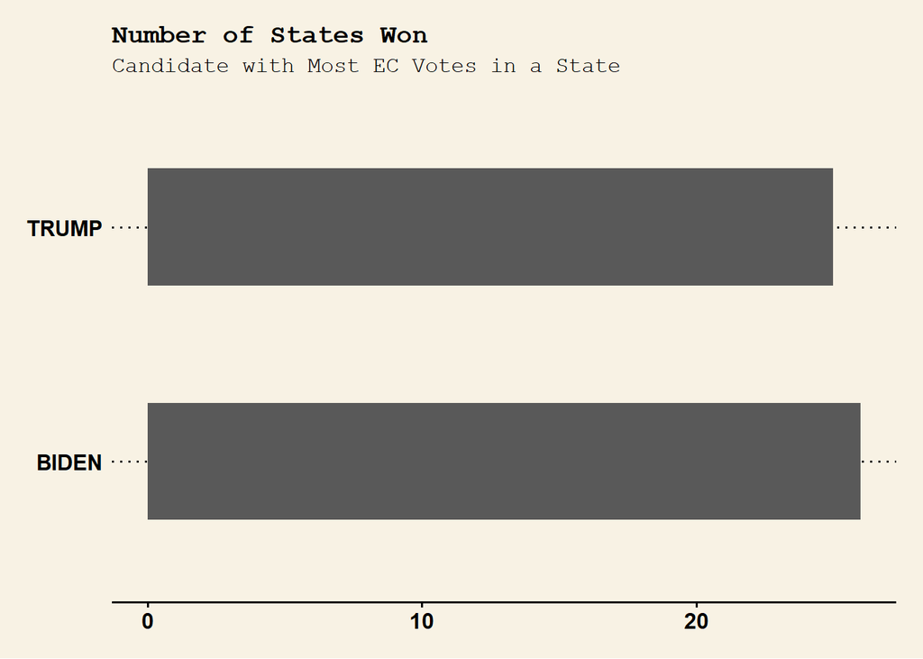

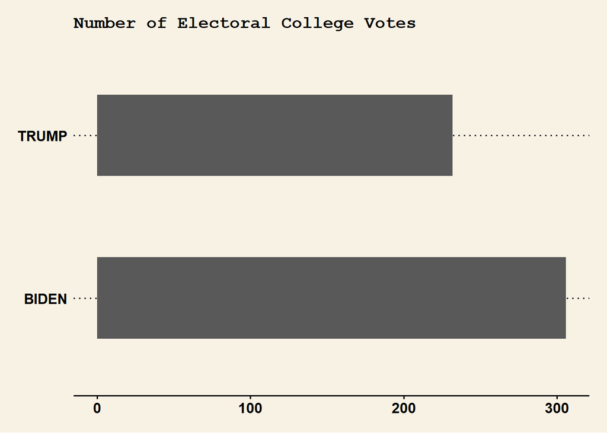

```r
ggplot(votes) +
  geom_bar(aes(y=EV_WINNER),width=0.5) +
  ggtitle("Number of States Won",subtitle="Candidate with Most EC Votes in a State") +
  xlab("") + my_theme()

evtibble = tibble(EV=c(sum(votes$EV_BIDEN),sum(votes$EV_TRUMP)),
  CANDIDATE=c("BIDEN","TRUMP"))

ggplot(evtibble) +
  geom_col(aes(x=EV,y=CANDIDATE),width=0.5) +
  ggtitle("Number of Electoral College Votes") +
  xlab("") +  my_theme()
```

And also take a look at the relative performance of the two candidates in each of the states.

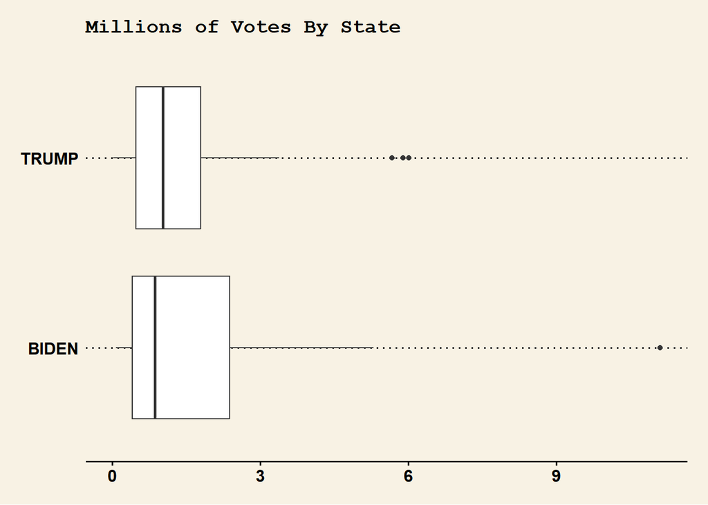

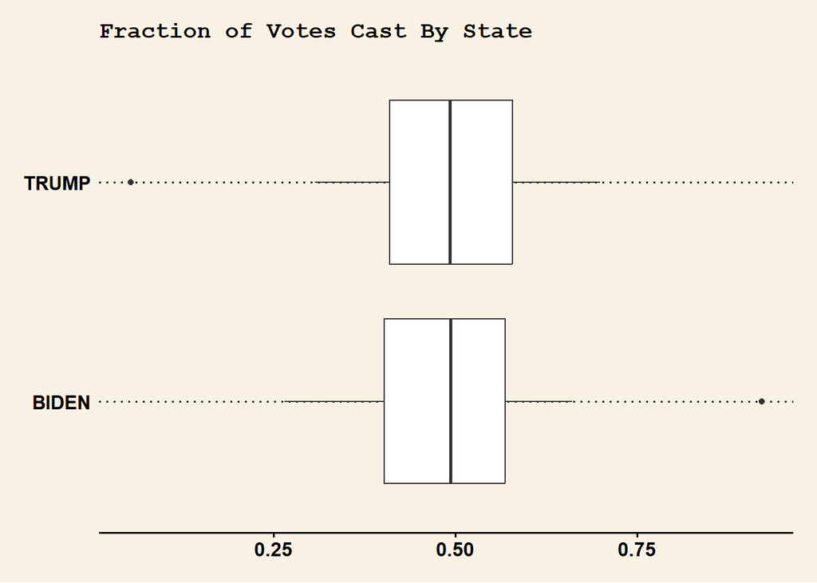

```r
biden_votes <- votes %>%
  select("STATE","BIDEN_MILLIONS","BIDEN_PCT") %>%
  mutate(CANDIDATE="BIDEN") %>%
  rename(MILLIONS=BIDEN_MILLIONS,PCT=BIDEN_PCT)

trump_votes <- votes %>%
  select("STATE","TRUMP_MILLIONS","TRUMP_PCT") %>%
  mutate(CANDIDATE="TRUMP") %>%
  rename(MILLIONS=TRUMP_MILLIONS,PCT=TRUMP_PCT)

bycandidate <- bind_rows(biden_votes,trump_votes)

ggplot(bycandidate) +
  geom_boxplot(aes(MILLIONS,CANDIDATE)) +
  ggtitle("Millions of Votes By State") +
  my_theme()

ggplot(bycandidate) +
  geom_boxplot(aes(PCT,CANDIDATE)) +
  ggtitle("Fraction of Votes Cast By State") +
  my_theme()
```

## All States are “Purple”: Side-by-Side State-Level Vote Counts By Candidate

And now let’s get to the original question: what is the mixture of “winning” and “losing” voters in each state?

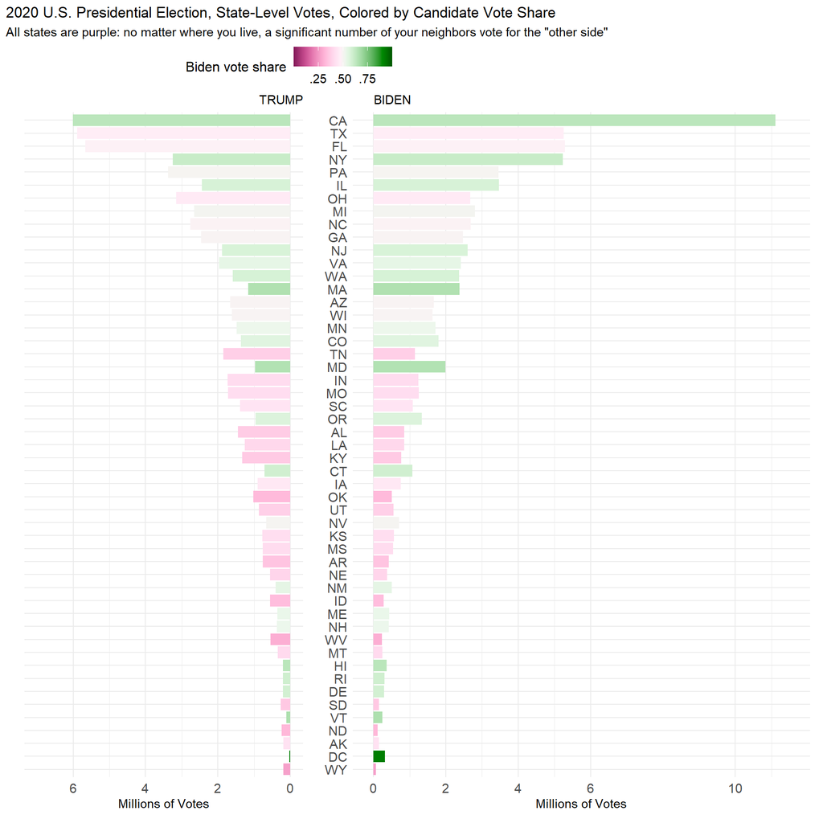

```r
ordered_by_vote_count <- votes %>%
  arrange(TOTAL_VOTES) %>%
  mutate(STATE=factor(STATE,levels=unique(STATE)))  # lock-in the re-arranged order of states

trump <- ordered_by_vote_count %>% mutate(MILLIONS=TRUMP_MILLIONS)
biden <- ordered_by_vote_count %>% mutate(MILLIONS=BIDEN_MILLIONS)

# Palettes that I like with the vote share feature (not sure if it's a sequential or
# diverging scale since it looks best when the mid-scale--0.5--is a separate color?)
#
# Purple-Green, Red-Green
# La Jolla, RdBu
# Oslo, BurgYl, RdGy, YlGn, OrRd, YlOrRd
# Reds, Oranges, Purples, Greens, Purples 2, Greens 2, Blues 3, Reds 2
# Grays, Light Grays, Teal, Burg, Red-Yellow, PuBuGn, YlOrBr
# Cork, Vik, Mako, Blue-Red 3, Purple-Blue, PRGn, BluGrn
mypalette <- "Red-Green"
myrev=F

###
# Optional: lLabel bars with number of votes
# bigstates = data %>% filter(MILLIONS >= 2.2)
# labels = formatC(bigstates$MILLIONS, digits = 1, format = "f")
#
# +geom_text(aes(x=MILLIONS-0.5,y=STATE,label=labels),data=bigstates,size=4)
###

mkplot <- function(data,xscale,candidate) {
   newplot <-ggplot(data,height=6) +
     geom_col(aes(MILLIONS,STATE,fill=BIDEN_PCT), linewidth=1) +
     xscale(breaks=c(0,2,4,6,10),minor_breaks=c(1,3,5,11)) +
     scale_fill_gradientn(name="Biden vote share",
                          colors=hcl.colors(n=20,palette=mypalette,rev=myrev),
                          limits=c(0,1),
                          breaks=c(0.25,0.5,0.75),
                          labels=c(".25",".50",".75"))+
     ggtitle(candidate) +
     xlab("Millions of Votes") +
     ylab("") +
     theme_minimal() +
     theme(axis.text=element_text(size=11.5))

   newplot
}

twid=7
bwid=11.5

tplot <- mkplot(trump,scale_x_reverse,"TRUMP") +
  coord_cartesian(c(twid,0)) +
  theme(
        axis.text.y=element_blank(),
        axis.ticks.x=element_blank(),
        plot.margin = margin(t=3,0,0,0, "lines"),
        plot.title = element_text(hjust = 1,size=11),
        legend.title = element_text(size=12),
        legend.text = element_text(size=11),
        legend.title.align = 0.5,
        legend.direction = "horizontal",
        legend.position = c(0.95,1.07))


bplot <- mkplot(biden,scale_x_continuous,"BIDEN") +
  theme(plot.title = element_text(hjust=0.05,size=11),
        legend.position="none") +
  coord_cartesian(c(0,bwid))


# using `patchwork` library to perform the plot layout here
tplot + bplot +
   plot_layout(widths=c(twid,bwid)) +
   plot_annotation(
     title="2020 U.S. Presidential Election, State-Level Votes, Colored by Candidate Vote Share",
     subtitle="All states are purple: no matter where you live, a significant number of your neighbors vote for the \"other side\"")
```

## Wasted Votes: State-Level Vote Counts Segregated By Losing Candidate

It is impressive to see the sheer number of votes for each candidate in states where they lost the electoral college votes. How many voters did not have a “representative” among the electoral college electors?

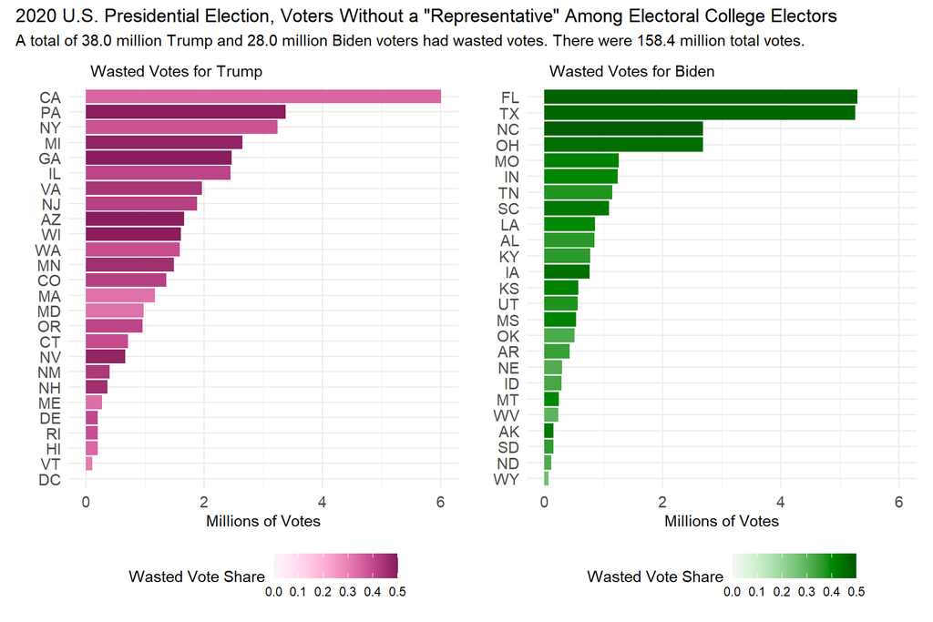

```r
############################################################
# Data
#
#
# Congressional district votes in Nebraska and Maine which were awarded a
# single "losing" elector are apportioned across all the voters in the state,
# e.g., 20% of Biden votes in Nebraska and 25% of Trump votes in
# Maine are not counted as wasted

twasted = votes %>%
  filter(EV_WINNER=="BIDEN") %>%
  mutate(WASTED = TRUMP * ((ELECTORAL_VOTES - EV_TRUMP) / ELECTORAL_VOTES),
         WASTED_MILLIONS = WASTED/1e6,
         WASTED_FRAC = WASTED/TOTAL_VOTES) %>%
  arrange(WASTED) %>%
  mutate(STATE=factor(STATE,levels=unique(STATE)))

bwasted = votes %>%
  filter(EV_WINNER=="TRUMP") %>%
  mutate(WASTED = BIDEN * ((ELECTORAL_VOTES - EV_BIDEN) / ELECTORAL_VOTES),
         WASTED_MILLIONS = WASTED/1e6,
         WASTED_FRAC = WASTED/TOTAL_VOTES) %>%
  arrange(WASTED) %>%
  mutate(STATE=factor(STATE,levels=unique(STATE)))

sum_bwasted <- sum(bwasted$WASTED_MILLIONS)
sum_twasted <- sum(twasted$WASTED_MILLIONS)
sum_all = sum(votes$TOTAL_VOTES)/1e6

############################################################
# Plots
#
wvpalette = "Red-Green"
trev=F
brev=T

wvcolorscaler <- function(x,to,from,...) {
  scales::rescale(x,from=c(0.0,0.5),to=c(0.5,0),...)
}


twasted_plot = ggplot(twasted) +
  geom_col(aes(x=WASTED_MILLIONS,y=STATE,fill=WASTED_FRAC)) +
  coord_cartesian(c(0,6)) +
  scale_fill_gradientn(name="Wasted Vote Share",
                       colors=hcl.colors(n=20,palette=wvpalette,rev=trev),
                       limits=c(0,0.5),
                       rescaler=wvcolorscaler) +
  xlab("Millions of Votes") +
  ylab("") +
  ggtitle("Wasted Votes for Trump") +
  theme_minimal() +
  theme(legend.position="bottom",
        legend.title.align = 0.5,
        axis.text = element_text(size=11),
        plot.title = element_text(hjust=0.1,size=11))

bwasted_plot = ggplot(bwasted) +
  geom_col(aes(x=WASTED_MILLIONS,y=STATE,fill=WASTED_FRAC)) +
  coord_cartesian(c(0,6)) +
  scale_fill_gradientn(name="Wasted Vote Share",
                       colors=hcl.colors(n=20,palette=wvpalette,rev=brev),
                       limits=c(0,0.5),
                       rescaler=wvcolorscaler) +
  xlab("Millions of Votes") +
  ylab("") +
  ggtitle("Wasted Votes for Biden") +
  theme_minimal() +
  theme(legend.position="bottom",
        legend.title.align = 0.5,
        axis.text = element_text(size=11),
        plot.title = element_text(hjust=0.1,size=11))

# using `patchwork` library
twasted_plot + bwasted_plot +
  plot_annotation(
    title="2020 U.S. Presidential Election, Voters Without a \"Representative\" Among Electoral College Electors",
    subtitle=sprintf("A total of %0.1f million Trump and %0.1f million Biden voters had wasted votes. There were %0.1f million total votes.",sum_twasted,sum_bwasted,sum_all))
```